# Logistic Regression

Installing all the packages:-

```r
library(dplyr)
library(readr)
library(ggplot2)
library(DescTools)
library(moments)
library(ISLR)
library(aod)
```

Reading Data:-

```r
data<-read.csv("Placement_Data_Full_Class.csv")
head(data)
```

|  | sl_no | gender | ssc_p | ssc_b | hsc_p | hsc_b | hsc_s | degree_p | degree_t | workex | etest_p | specialisation | mba_p | status | salary |
| --- | --- | --- | --- | --- | --- | --- | --- | --- | --- | --- | --- | --- | --- | --- | --- |
| 1 | 1 | M | 67.00 | Others | 91.00 | Others | Commerce | 58.00 | Sci&Tech | No | 55.0 | Mkt&HR | 58.80 | Placed | 270000 |
| 2 | 2 | M | 79.33 | Central | 78.33 | Others | Science | 77.48 | Sci&Tech | Yes | 86.5 | Mkt&Fin | 66.28 | Placed | 200000 |
| 3 | 3 | M | 65.00 | Central | 68.00 | Central | Arts | 64.00 | Comm&Mgmt | No | 75.0 | Mkt&Fin | 57.80 | Placed | 250000 |
| 4 | 4 | M | 56.00 | Central | 52.00 | Central | Science | 52.00 | Sci&Tech | No | 66.0 | Mkt&HR | 59.43 | Not Placed | NA |
| 5 | 5 | M | 85.80 | Central | 73.60 | Central | Commerce | 73.30 | Comm&Mgmt | No | 96.8 | Mkt&Fin | 55.50 | Placed | 425000 |
| 6 | 6 | M | 55.00 | Others | 49.80 | Others | Science | 67.25 | Sci&Tech | Yes | 55.0 | Mkt&Fin | 51.58 | Not Placed | NA |

Gaining insights from the data:-

```r
summary(data)
```

```
     sl_no          gender              ssc_p          ssc_b
 Min.   :  1.0   Length:215         Min.   :40.89   Length:215
 1st Qu.: 54.5   Class :character   1st Qu.:60.60   Class :character
 Median :108.0   Mode  :character   Median :67.00   Mode  :character
 Mean   :108.0                      Mean   :67.30
 3rd Qu.:161.5                      3rd Qu.:75.70
 Max.   :215.0                      Max.   :89.40

     hsc_p          hsc_b              hsc_s              degree_p
 Min.   :37.00   Length:215         Length:215         Min.   :50.00
 1st Qu.:60.90   Class :character   Class :character   1st Qu.:61.00
 Median :65.00   Mode  :character   Mode  :character   Median :66.00
 Mean   :66.33                                         Mean   :66.37
 3rd Qu.:73.00                                         3rd Qu.:72.00
 Max.   :97.70                                         Max.   :91.00

   degree_t            workex             etest_p     specialisation
 Length:215         Length:215         Min.   :50.0   Length:215
 Class :character   Class :character   1st Qu.:60.0   Class :character
 Mode  :character   Mode  :character   Median :71.0   Mode  :character
                                       Mean   :72.1
                                       3rd Qu.:83.5
                                       Max.   :98.0

     mba_p          status              salary
 Min.   :51.21   Length:215         Min.   :200000
 1st Qu.:57.95   Class :character   1st Qu.:240000
 Median :62.00   Mode  :character   Median :265000
 Mean   :62.28                      Mean   :288655
 3rd Qu.:66.25                      3rd Qu.:300000
 Max.   :77.89                      Max.   :940000
                                    NA's   :67
```

```r
str(data)
```

```
'data.frame':   215 obs. of  15 variables:
 $ sl_no         : int  1 2 3 4 5 6 7 8 9 10 ...
 $ gender        : chr  "M" "M" "M" "M" ...
 $ ssc_p         : num  67 79.3 65 56 85.8 ...
 $ ssc_b         : chr  "Others" "Central" "Central" "Central" ...
 $ hsc_p         : num  91 78.3 68 52 73.6 ...
 $ hsc_b         : chr  "Others" "Others" "Central" "Central" ...
 $ hsc_s         : chr  "Commerce" "Science" "Arts" "Science" ...
 $ degree_p      : num  58 77.5 64 52 73.3 ...
 $ degree_t      : chr  "Sci&Tech" "Sci&Tech" "Comm&Mgmt" "Sci&Tech" ...
 $ workex        : chr  "No" "Yes" "No" "No" ...
 $ etest_p       : num  55 86.5 75 66 96.8 ...
 $ specialisation: chr  "Mkt&HR" "Mkt&Fin" "Mkt&Fin" "Mkt&HR" ...
 $ mba_p         : num  58.8 66.3 57.8 59.4 55.5 ...
 $ status        : chr  "Placed" "Placed" "Placed" "Not Placed" ...
 $ salary        : int  270000 200000 250000 NA 425000 NA NA 252000 231000 NA ...
```

Removing NA values from salary(if not placed) to 0:-

```r
data$salary[is.na(data$salary)]<-0;
head(data)
```

|  | sl_no | gender | ssc_p | ssc_b | hsc_p | hsc_b | hsc_s | degree_p | degree_t | workex | etest_p | specialisation | mba_p | status | salary |
| --- | --- | --- | --- | --- | --- | --- | --- | --- | --- | --- | --- | --- | --- | --- | --- |
| 1 | 1 | M | 67.00 | Others | 91.00 | Others | Commerce | 58.00 | Sci&Tech | No | 55.0 | Mkt&HR | 58.80 | Placed | 270000 |
| 2 | 2 | M | 79.33 | Central | 78.33 | Others | Science | 77.48 | Sci&Tech | Yes | 86.5 | Mkt&Fin | 66.28 | Placed | 200000 |
| 3 | 3 | M | 65.00 | Central | 68.00 | Central | Arts | 64.00 | Comm&Mgmt | No | 75.0 | Mkt&Fin | 57.80 | Placed | 250000 |
| 4 | 4 | M | 56.00 | Central | 52.00 | Central | Science | 52.00 | Sci&Tech | No | 66.0 | Mkt&HR | 59.43 | Not Placed | 0 |
| 5 | 5 | M | 85.80 | Central | 73.60 | Central | Commerce | 73.30 | Comm&Mgmt | No | 96.8 | Mkt&Fin | 55.50 | Placed | 425000 |
| 6 | 6 | M | 55.00 | Others | 49.80 | Others | Science | 67.25 | Sci&Tech | Yes | 55.0 | Mkt&Fin | 51.58 | Not Placed | 0 |

Feature selection:-

```r
data<-subset(data,select = -c(sl_no,ssc_b,hsc_b))
head(data)
```

|  | gender | ssc_p | hsc_p | hsc_s | degree_p | degree_t | workex | etest_p | specialisation | mba_p | status | salary |
| --- | --- | --- | --- | --- | --- | --- | --- | --- | --- | --- | --- | --- |
| 1 | M | 67.00 | 91.00 | Commerce | 58.00 | Sci&Tech | No | 55.0 | Mkt&HR | 58.80 | Placed | 270000 |
| 2 | M | 79.33 | 78.33 | Science | 77.48 | Sci&Tech | Yes | 86.5 | Mkt&Fin | 66.28 | Placed | 200000 |
| 3 | M | 65.00 | 68.00 | Arts | 64.00 | Comm&Mgmt | No | 75.0 | Mkt&Fin | 57.80 | Placed | 250000 |
| 4 | M | 56.00 | 52.00 | Science | 52.00 | Sci&Tech | No | 66.0 | Mkt&HR | 59.43 | Not Placed | 0 |
| 5 | M | 85.80 | 73.60 | Commerce | 73.30 | Comm&Mgmt | No | 96.8 | Mkt&Fin | 55.50 | Placed | 425000 |
| 6 | M | 55.00 | 49.80 | Science | 67.25 | Sci&Tech | Yes | 55.0 | Mkt&Fin | 51.58 | Not Placed | 0 |

Checking for outliers:-

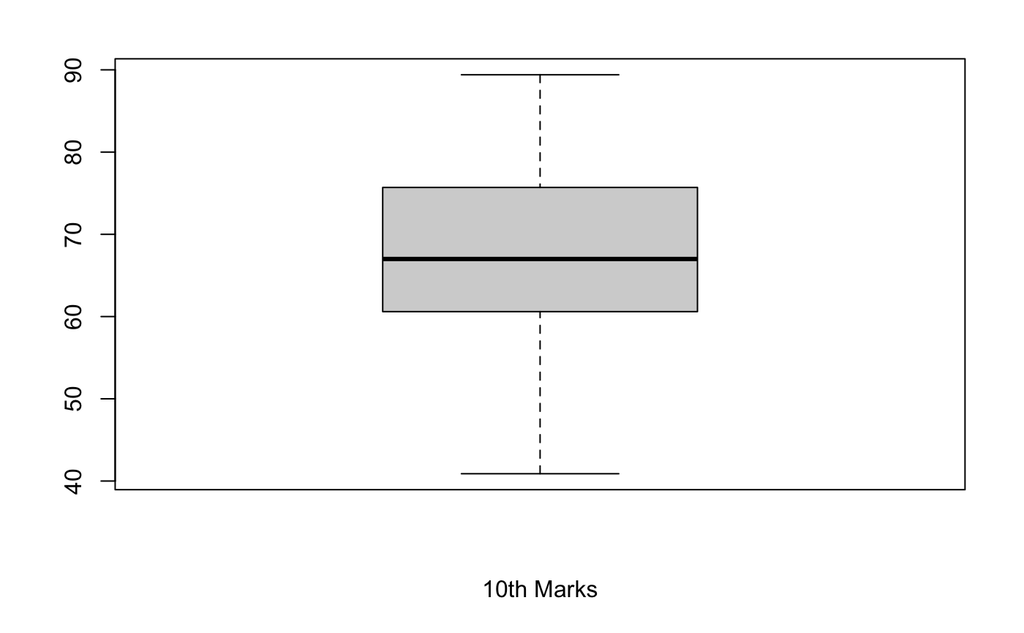

```r
boxplot(data$ssc_p,xlab="10th Marks")
```

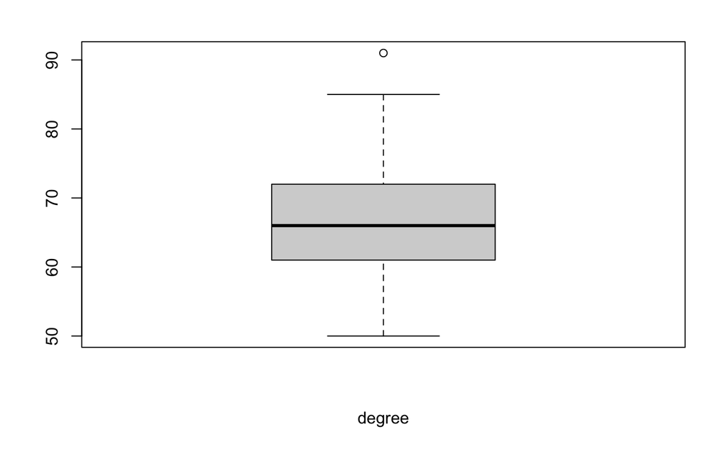

```r
boxplot(data$degree_p,xlab="degree")
```

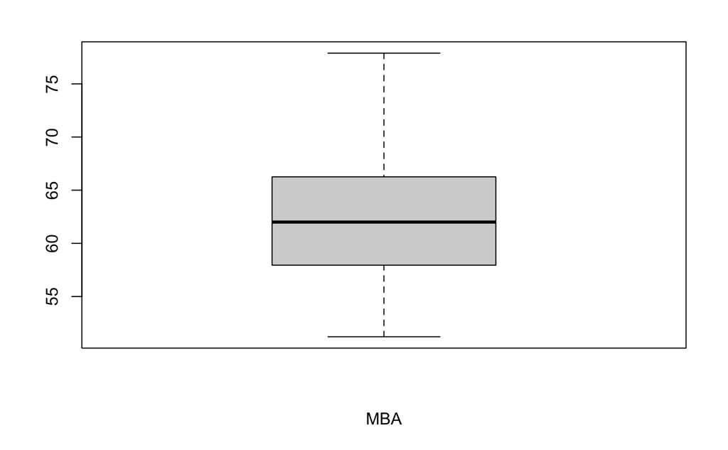

```r
boxplot(data$mba_p,xlab="MBA")
```

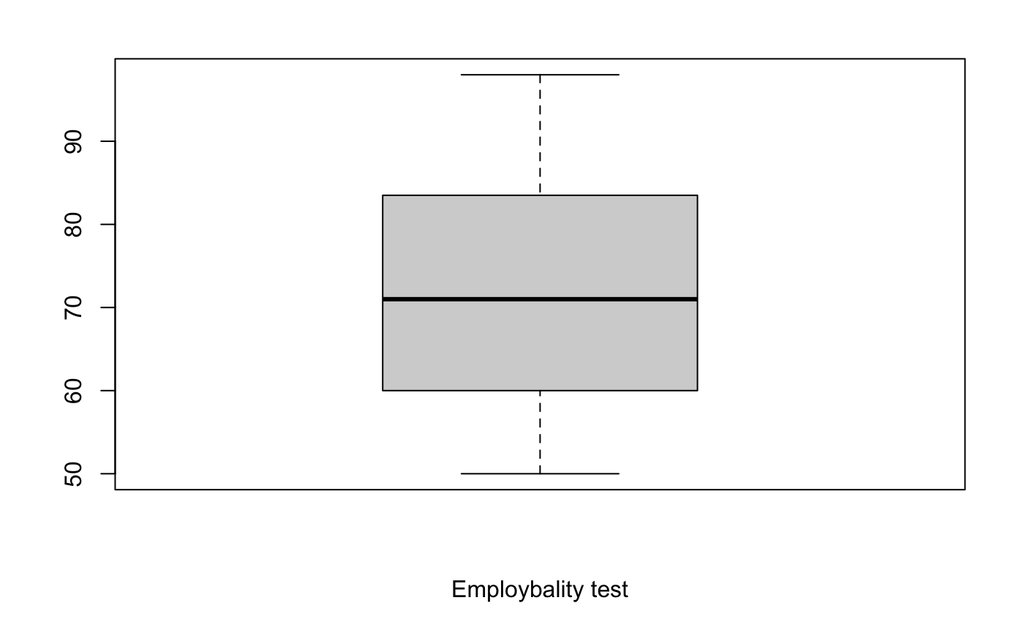

```r
boxplot(data$etest_p,xlab="Employbality test")
```

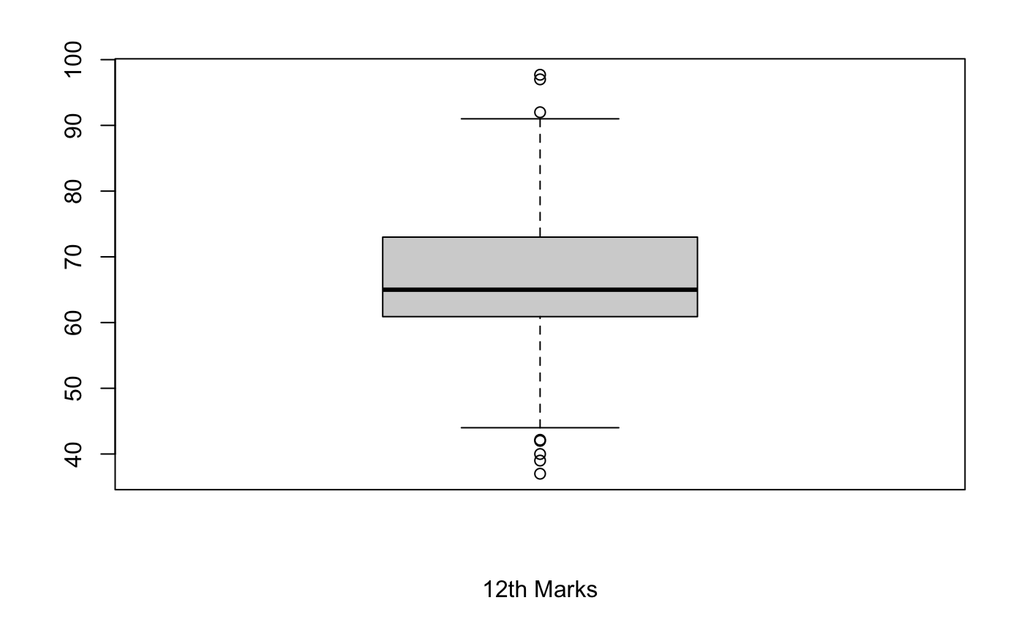

```r
boxplot(data$hsc_p,xlab="12th Marks")
```

so there is outliers in column hsc_p. No other columns have a significant amount of outliers.

Removing outliers from hsc_p column:-

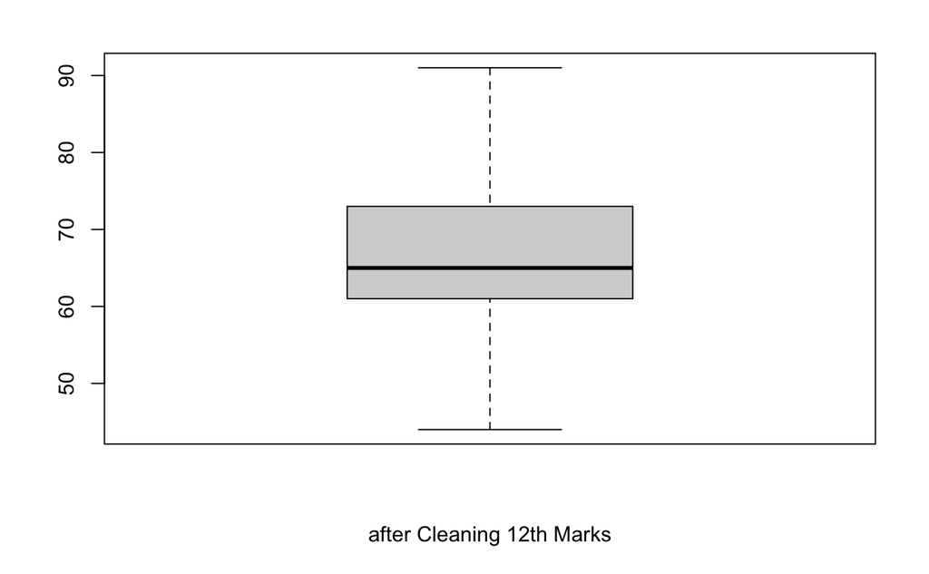

```r
q1<-quantile(data$hsc_p,0.25)
q3<-quantile(data$hsc_p,0.75)
iqr<-1.5*(q3-q1)
data<- data %>% filter(data$hsc_p>=q1-iqr,data$hsc_p<=q3+iqr)
boxplot(data$hsc_p,xlab="after Cleaning 12th Marks")
```

Preparing the data for the model Logistic Regression

Identifying the unique data in the categorical columns:-

```r
unique(data$hsc_s,incomparables = FALSE)
```

```
[1] "Commerce" "Science"  "Arts"
```

```r
unique(data$degree_t,incomparables = FALSE)
```

```
[1] "Sci&Tech"  "Comm&Mgmt" "Others"
```

```r
unique(data$specialisation,incomparables = FALSE)
```

```
[1] "Mkt&HR"  "Mkt&Fin"
```

Replacing the categorical values with corresponding numbers:-

```r
data$workex<-as.numeric(as.factor(data$workex))-1
data$gender<-as.numeric(as.factor(data$gender))-1
data$specialisation<-as.numeric(as.factor(data$specialisation))-1
data$status<-as.numeric(as.factor(data$status))-1
data
```

| gender | ssc_p | hsc_p | hsc_s | degree_p | degree_t | workex | etest_p | specialisation | mba_p | status | salary |
| --- | --- | --- | --- | --- | --- | --- | --- | --- | --- | --- | --- |
| 1 | 67.00 | 91.00 | Commerce | 58.00 | Sci&Tech | 0 | 55.00 | 1 | 58.80 | 1 | 270000 |
| 1 | 79.33 | 78.33 | Science | 77.48 | Sci&Tech | 1 | 86.50 | 0 | 66.28 | 1 | 200000 |
| 1 | 65.00 | 68.00 | Arts | 64.00 | Comm&Mgmt | 0 | 75.00 | 0 | 57.80 | 1 | 250000 |
| 1 | 56.00 | 52.00 | Science | 52.00 | Sci&Tech | 0 | 66.00 | 1 | 59.43 | 0 | 0 |
| 1 | 85.80 | 73.60 | Commerce | 73.30 | Comm&Mgmt | 0 | 96.80 | 0 | 55.50 | 1 | 425000 |
| 1 | 55.00 | 49.80 | Science | 67.25 | Sci&Tech | 1 | 55.00 | 0 | 51.58 | 0 | 0 |
| 0 | 46.00 | 49.20 | Commerce | 79.00 | Comm&Mgmt | 0 | 74.28 | 0 | 53.29 | 0 | 0 |
| 1 | 82.00 | 64.00 | Science | 66.00 | Sci&Tech | 1 | 67.00 | 0 | 62.14 | 1 | 252000 |
| 1 | 73.00 | 79.00 | Commerce | 72.00 | Comm&Mgmt | 0 | 91.34 | 0 | 61.29 | 1 | 231000 |
| 1 | 58.00 | 70.00 | Commerce | 61.00 | Comm&Mgmt | 0 | 54.00 | 0 | 52.21 | 0 | 0 |

[output cut: 197 more lines]

```r
#library(caret)
#scales <- list(x=list(relation="free"), y=list(relation="free"))
#featurePlot(x=data[,2:3], y=data$status, plot="density")
```

Creating dummy variables for qualitative columns:-

```r
data<- data %>% mutate(
  Commerce=case_when(hsc_s=="Commerce"~1,TRUE~0),
  Arts=case_when(hsc_s=="Arts"~1,TRUE~0),
  Science=case_when(hsc_s=="Science"~1,TRUE~0),
  SciTech=case_when(degree_t=="Sci&Tech"~1,TRUE~0),
  CommMgmt=case_when(degree_t=="Comm&Mgmt"~1,TRUE~0),
  Others=case_when(degree_t=="Others"~1,TRUE~0),
  )
data<-subset(data,select = -c(hsc_s,degree_t,salary))
head(data)
```

|  | gender | ssc_p | hsc_p | degree_p | workex | etest_p | specialisation | mba_p | status | Commerce | Arts | Science | SciTech | CommMgmt | Others |
| --- | --- | --- | --- | --- | --- | --- | --- | --- | --- | --- | --- | --- | --- | --- | --- |
| 1 | 1 | 67.00 | 91.00 | 58.00 | 0 | 55.0 | 1 | 58.80 | 1 | 1 | 0 | 0 | 1 | 0 | 0 |
| 2 | 1 | 79.33 | 78.33 | 77.48 | 1 | 86.5 | 0 | 66.28 | 1 | 0 | 0 | 1 | 1 | 0 | 0 |
| 3 | 1 | 65.00 | 68.00 | 64.00 | 0 | 75.0 | 0 | 57.80 | 1 | 0 | 1 | 0 | 0 | 1 | 0 |
| 4 | 1 | 56.00 | 52.00 | 52.00 | 0 | 66.0 | 1 | 59.43 | 0 | 0 | 0 | 1 | 1 | 0 | 0 |
| 5 | 1 | 85.80 | 73.60 | 73.30 | 0 | 96.8 | 0 | 55.50 | 1 | 1 | 0 | 0 | 0 | 1 | 0 |
| 6 | 1 | 55.00 | 49.80 | 67.25 | 1 | 55.0 | 0 | 51.58 | 0 | 0 | 0 | 1 | 1 | 0 | 0 |

Testing the model locally

Model Creation with all parameters:-

```r
model1<-glm(status~gender+ssc_p+hsc_p+degree_p+workex+etest_p+specialisation+mba_p+Commerce+Arts+Science+SciTech+CommMgmt+Others , data=data, family=binomial)
summary(model1)
```

```
Call:
glm(formula = status ~ gender + ssc_p + hsc_p + degree_p + workex +
    etest_p + specialisation + mba_p + Commerce + Arts + Science +
    SciTech + CommMgmt + Others, family = binomial, data = data)

Deviance Residuals:
     Min        1Q    Median        3Q       Max
-2.41915  -0.14397   0.08541   0.30871   2.36440

Coefficients: (2 not defined because of singularities)
                Estimate Std. Error z value Pr(>|z|)
(Intercept)    -19.76027    5.47774  -3.607 0.000309 ***
gender           1.34242    0.66305   2.025 0.042906 *
ssc_p            0.22431    0.04291   5.228 1.72e-07 ***
hsc_p            0.09889    0.03676   2.690 0.007143 **
degree_p         0.18482    0.05560   3.324 0.000887 ***
workex           2.01495    0.70164   2.872 0.004082 **
etest_p         -0.01581    0.02189  -0.722 0.470211
specialisation  -0.28472    0.54797  -0.520 0.603341
mba_p           -0.20210    0.05569  -3.629 0.000285 ***
Commerce        -0.64701    0.75226  -0.860 0.389738
Arts             0.78504    1.42262   0.552 0.581068
Science               NA         NA      NA       NA
SciTech         -0.71639    1.64054  -0.437 0.662345
CommMgmt         1.01313    1.50869   0.672 0.501884
Others                NA         NA      NA       NA
---
Signif. codes:  0 ‘***’ 0.001 ‘**’ 0.01 ‘*’ 0.05 ‘.’ 0.1 ‘ ’ 1

(Dispersion parameter for binomial family taken to be 1)

    Null deviance: 252.73  on 206  degrees of freedom
Residual deviance: 100.22  on 194  degrees of freedom
AIC: 126.22

Number of Fisher Scoring iterations: 7
```

We see that gender,ssc_p,hsc_p,degree_p,workex,mba_p are statistically significant at 0.05 (ie.. 95% confidence interval)

ANOVA test for the overall logistic model:-

```r
anova(model1,test = 'Chisq')
```

```
Analysis of Deviance Table

Model: binomial, link: logit

Response: status

Terms added sequentially (first to last)

               Df Deviance Resid. Df Resid. Dev  Pr(>Chi)
NULL                             206     252.73
gender          1    2.618       205     250.11 0.1056389
ssc_p           1   92.103       204     158.01 < 2.2e-16 ***
hsc_p           1   14.981       203     143.03 0.0001086 ***
degree_p        1    8.722       202     134.31 0.0031445 **
workex          1    8.112       201     126.19 0.0043976 **
etest_p         1    0.945       200     125.25 0.3309516
specialisation  1    0.768       199     124.48 0.3808594
mba_p           1   17.012       198     107.47 3.714e-05 ***
Commerce        1    0.023       197     107.44 0.8790968
Arts            1    1.571       196     105.87 0.2100312
Science         0    0.000       196     105.87
SciTech         1    5.175       195     100.70 0.0229093 *
CommMgmt        1    0.479       194     100.22 0.4886626
Others          0    0.000       194     100.22
---
Signif. codes:  0 ‘***’ 0.001 ‘**’ 0.01 ‘*’ 0.05 ‘.’ 0.1 ‘ ’ 1
```

We see that ssc_p,hsc_p,degree_p,workex,mba_p are statistically significant.

Developing a model with these parameters:-

```r
model2<-glm(status~gender+ssc_p+hsc_p+degree_p+workex+mba_p,data=data,family=binomial)
summary(model2)
```

```
Call:
glm(formula = status ~ gender + ssc_p + hsc_p + degree_p + workex +
    mba_p, family = binomial, data = data)

Deviance Residuals:
     Min        1Q    Median        3Q       Max
-2.25412  -0.15955   0.09118   0.36926   2.34286

Coefficients:
             Estimate Std. Error z value Pr(>|z|)
(Intercept) -19.09656    4.72283  -4.043 5.27e-05 ***
gender        1.08697    0.57625   1.886  0.05925 .
ssc_p         0.20384    0.04080   4.996 5.84e-07 ***
hsc_p         0.11553    0.03571   3.235  0.00122 **
degree_p      0.16321    0.05028   3.246  0.00117 **
workex        2.06250    0.64625   3.191  0.00142 **
mba_p        -0.20172    0.05132  -3.931 8.47e-05 ***
---
Signif. codes:  0 ‘***’ 0.001 ‘**’ 0.01 ‘*’ 0.05 ‘.’ 0.1 ‘ ’ 1

(Dispersion parameter for binomial family taken to be 1)

    Null deviance: 252.73  on 206  degrees of freedom
Residual deviance: 108.62  on 200  degrees of freedom
AIC: 122.62

Number of Fisher Scoring iterations: 7
```

ANOVA test:-

```r
anova(model1,model2,test = 'Chisq')
```

```
Analysis of Deviance Table

Model 1: status ~ gender + ssc_p + hsc_p + degree_p + workex + etest_p +
    specialisation + mba_p + Commerce + Arts + Science + SciTech +
    CommMgmt + Others
Model 2: status ~ gender + ssc_p + hsc_p + degree_p + workex + mba_p
  Resid. Df Resid. Dev Df Deviance Pr(>Chi)
1       194     100.22
2       200     108.62 -6  -8.4023   0.2101
```

Now we got a general idea of what parameters to consider for the model.

Splitting data set into training and testing data:-

```r
library(caret)
set.seed(3456)
split <- createDataPartition(y = data$status,p = 0.67,list = FALSE)
```

```r
new_train <- data[split,]
new_train
```

|  | gender | ssc_p | hsc_p | degree_p | workex | etest_p | specialisation | mba_p | status | Commerce | Arts | Science | SciTech | CommMgmt | Others |
| --- | --- | --- | --- | --- | --- | --- | --- | --- | --- | --- | --- | --- | --- | --- | --- |
| 2 | 1 | 79.33 | 78.33 | 77.48 | 1 | 86.50 | 0 | 66.28 | 1 | 0 | 0 | 1 | 1 | 0 | 0 |
| 6 | 1 | 55.00 | 49.80 | 67.25 | 1 | 55.00 | 0 | 51.58 | 0 | 0 | 0 | 1 | 1 | 0 | 0 |
| 8 | 1 | 82.00 | 64.00 | 66.00 | 1 | 67.00 | 0 | 62.14 | 1 | 0 | 0 | 1 | 1 | 0 | 0 |
| 10 | 1 | 58.00 | 70.00 | 61.00 | 0 | 54.00 | 0 | 52.21 | 0 | 1 | 0 | 0 | 0 | 1 | 0 |
| 11 | 1 | 58.00 | 61.00 | 60.00 | 1 | 62.00 | 1 | 60.85 | 1 | 1 | 0 | 0 | 0 | 1 | 0 |
| 12 | 1 | 69.60 | 68.40 | 78.30 | 1 | 60.00 | 0 | 63.70 | 1 | 1 | 0 | 0 | 0 | 1 | 0 |
| 13 | 0 | 47.00 | 55.00 | 65.00 | 0 | 62.00 | 1 | 65.04 | 0 | 0 | 0 | 1 | 0 | 1 | 0 |
| 14 | 0 | 77.00 | 87.00 | 59.00 | 0 | 68.00 | 0 | 68.63 | 1 | 1 | 0 | 0 | 0 | 1 | 0 |
| 15 | 1 | 62.00 | 47.00 | 50.00 | 0 | 76.00 | 1 | 54.96 | 0 | 1 | 0 | 0 | 0 | 1 | 0 |
| 16 | 0 | 65.00 | 75.00 | 69.00 | 1 | 72.00 | 0 | 64.66 | 1 | 1 | 0 | 0 | 0 | 1 | 0 |

[output cut: 129 more lines]

```r
new_test <-data[-split,]
new_test
```

|  | gender | ssc_p | hsc_p | degree_p | workex | etest_p | specialisation | mba_p | status | Commerce | Arts | Science | SciTech | CommMgmt | Others |
| --- | --- | --- | --- | --- | --- | --- | --- | --- | --- | --- | --- | --- | --- | --- | --- |
| 1 | 1 | 67.00 | 91.00 | 58.00 | 0 | 55.00 | 1 | 58.80 | 1 | 1 | 0 | 0 | 1 | 0 | 0 |
| 3 | 1 | 65.00 | 68.00 | 64.00 | 0 | 75.00 | 0 | 57.80 | 1 | 0 | 1 | 0 | 0 | 1 | 0 |
| 4 | 1 | 56.00 | 52.00 | 52.00 | 0 | 66.00 | 1 | 59.43 | 0 | 0 | 0 | 1 | 1 | 0 | 0 |
| 5 | 1 | 85.80 | 73.60 | 73.30 | 0 | 96.80 | 0 | 55.50 | 1 | 1 | 0 | 0 | 0 | 1 | 0 |
| 7 | 0 | 46.00 | 49.20 | 79.00 | 0 | 74.28 | 0 | 53.29 | 0 | 1 | 0 | 0 | 0 | 1 | 0 |
| 9 | 1 | 73.00 | 79.00 | 72.00 | 0 | 91.34 | 0 | 61.29 | 1 | 1 | 0 | 0 | 0 | 1 | 0 |
| 17 | 1 | 63.00 | 66.20 | 65.60 | 1 | 60.00 | 0 | 62.54 | 1 | 1 | 0 | 0 | 0 | 1 | 0 |
| 18 | 0 | 55.00 | 67.00 | 64.00 | 0 | 60.00 | 0 | 67.28 | 0 | 1 | 0 | 0 | 0 | 1 | 0 |
| 20 | 1 | 60.00 | 67.00 | 70.00 | 1 | 50.48 | 0 | 77.89 | 1 | 0 | 1 | 0 | 0 | 1 | 0 |
| 22 | 0 | 79.00 | 76.00 | 85.00 | 0 | 95.00 | 0 | 69.06 | 1 | 1 | 0 | 0 | 0 | 1 | 0 |

[output cut: 58 more lines]

Applying the model for the training data set

```r
log_model<-glm(status~gender+ssc_p+hsc_p+degree_p+workex+mba_p,data=new_train,family=binomial)
summary(log_model)
```

```
Call:
glm(formula = status ~ gender + ssc_p + hsc_p + degree_p + workex +
    mba_p, family = binomial, data = new_train)

Deviance Residuals:
     Min        1Q    Median        3Q       Max
-2.24802  -0.10399   0.06784   0.39247   2.12222

Coefficients:
             Estimate Std. Error z value Pr(>|z|)
(Intercept) -19.83519    6.28157  -3.158 0.001590 **
gender        1.27813    0.75112   1.702 0.088823 .
ssc_p         0.18453    0.05174   3.566 0.000362 ***
hsc_p         0.13554    0.05347   2.535 0.011245 *
degree_p      0.21308    0.07085   3.008 0.002634 **
workex        2.41382    0.85214   2.833 0.004616 **
mba_p        -0.24509    0.07178  -3.415 0.000639 ***
---
Signif. codes:  0 ‘***’ 0.001 ‘**’ 0.01 ‘*’ 0.05 ‘.’ 0.1 ‘ ’ 1

(Dispersion parameter for binomial family taken to be 1)

    Null deviance: 168.617  on 138  degrees of freedom
Residual deviance:  66.688  on 132  degrees of freedom
AIC: 80.688

Number of Fisher Scoring iterations: 7
```

Predicting the model for the testing dataset

```r
log_predict <- predict(log_model,newdata = new_test,type = "response")
log_predict <- ifelse(log_predict > 0.5,1,0)
```

Setting the threshold to see the max accuracy.

Plotting the ROC curve:-

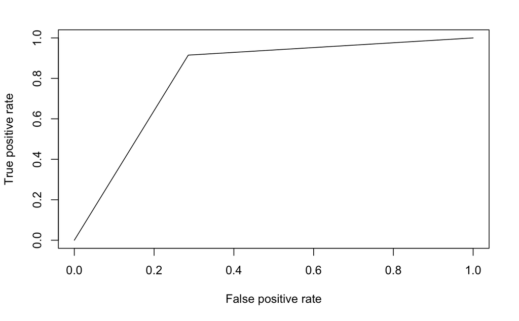

```r
library(ROCR)
library(Metrics)
pr <- prediction(log_predict,new_test$status)
perf <- performance(pr,measure = "tpr",x.measure = "fpr")
plot(perf)
```

Accuracy:-

```r
auc(new_test$status,log_predict)
```

```
[1] 0.8145897
```

Confusion Matriv for threshold=0.5

```r
library(caret)
final<-factor(log_predict)
levels(final)
```

```
[1] "0" "1"
```

```r
attach(new_test)
test<-factor(status)
levels(test)
```

```
[1] "0" "1"
```

```r
confusionMatrix(final, test)
```

```
Confusion Matrix and Statistics

          Reference
Prediction  0  1
         0 15  4
         1  6 43

               Accuracy : 0.8529
                 95% CI : (0.7461, 0.9272)
    No Information Rate : 0.6912
    P-Value [Acc > NIR] : 0.001773

                  Kappa : 0.6462

 Mcnemar's Test P-Value : 0.751830

            Sensitivity : 0.7143
            Specificity : 0.9149
         Pos Pred Value : 0.7895
         Neg Pred Value : 0.8776
             Prevalence : 0.3088
         Detection Rate : 0.2206
   Detection Prevalence : 0.2794
      Balanced Accuracy : 0.8146

       'Positive' Class : 0
```

Choosing a lower threshold (ie.. 0.4)

```r
log_predict <- predict(log_model,newdata = new_test,type = "response")
log_predict <- ifelse(log_predict > 0.4,1,0)
```

Plotting ROC curve:-

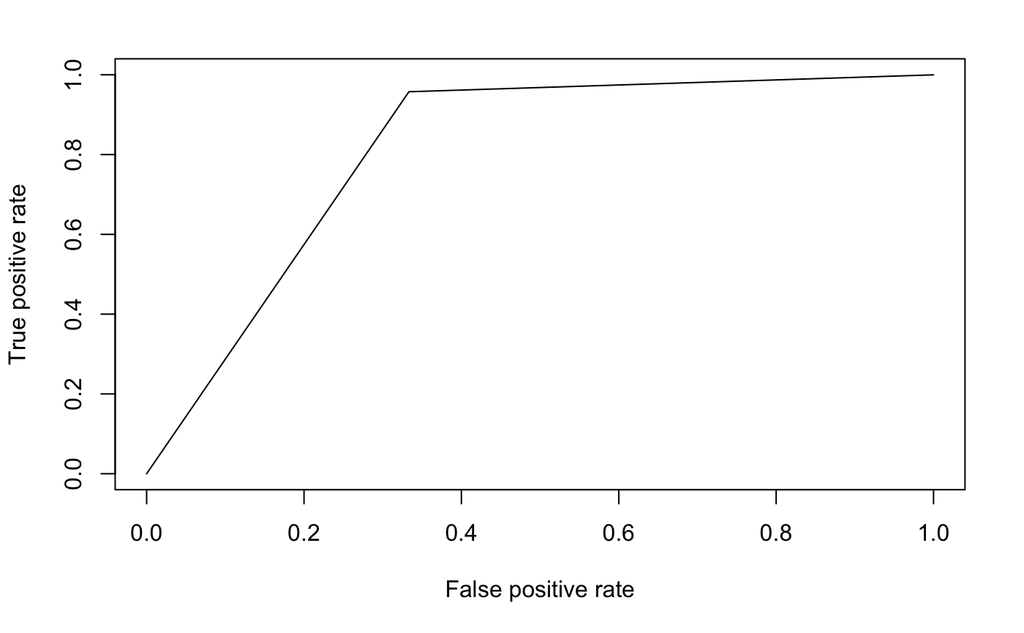

```r
library(ROCR)
library(Metrics)
pr <- prediction(log_predict,new_test$status)
perf <- performance(pr,measure = "tpr",x.measure = "fpr")
plot(perf)
```

Accuracy:-

```r
auc(new_test$status,log_predict)
```

```
[1] 0.8120567
```

No significant change in Accuracy

Confusion matrix for thres=0.4

```r
library(caret)
final<-factor(log_predict)
levels(final)
```

```
[1] "0" "1"
```

```r
attach(new_test)
test<-factor(status)
levels(test)
```

```
[1] "0" "1"
```

```r
confusionMatrix(final, test)
```

```
Confusion Matrix and Statistics

          Reference
Prediction  0  1
         0 14  2
         1  7 45

               Accuracy : 0.8676
                 95% CI : (0.7636, 0.9377)
    No Information Rate : 0.6912
    P-Value [Acc > NIR] : 0.0006336

                  Kappa : 0.6681

 Mcnemar's Test P-Value : 0.1824224

            Sensitivity : 0.6667
            Specificity : 0.9574
         Pos Pred Value : 0.8750
         Neg Pred Value : 0.8654
             Prevalence : 0.3088
         Detection Rate : 0.2059
   Detection Prevalence : 0.2353
      Balanced Accuracy : 0.8121

       'Positive' Class : 0
```

Threshold =0.6

```r
log_predict <- predict(log_model,newdata = new_test,type = "response")
log_predict <- ifelse(log_predict > 0.6,1,0)
```

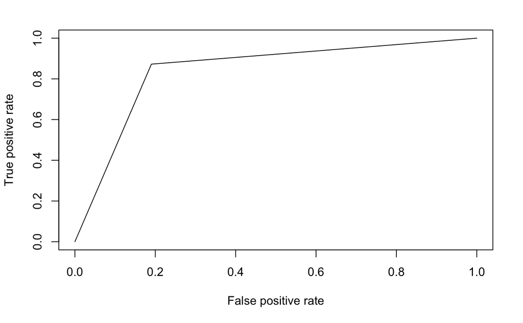

```r
library(ROCR)
library(Metrics)
pr <- prediction(log_predict,new_test$status)
perf <- performance(pr,measure = "tpr",x.measure = "fpr")
plot(perf)
```

```r
auc(new_test$status,log_predict)
```

```
[1] 0.8409321
```

```r
library(caret)
final<-factor(log_predict)
levels(final)
```

```
[1] "0" "1"
```

```r
attach(new_test)
test<-factor(status)
levels(test)
```

```
[1] "0" "1"
```

```r
confusionMatrix(final, test)
```

```
Confusion Matrix and Statistics

          Reference
Prediction  0  1
         0 17  6
         1  4 41

               Accuracy : 0.8529
                 95% CI : (0.7461, 0.9272)
    No Information Rate : 0.6912
    P-Value [Acc > NIR] : 0.001773

                  Kappa : 0.6644

 Mcnemar's Test P-Value : 0.751830

            Sensitivity : 0.8095
            Specificity : 0.8723
         Pos Pred Value : 0.7391
         Neg Pred Value : 0.9111
             Prevalence : 0.3088
         Detection Rate : 0.2500
   Detection Prevalence : 0.3382
      Balanced Accuracy : 0.8409

       'Positive' Class : 0
```

Diagnostic test

McFadden’s R squared

```r
null_model<-glm(status~1,data=new_train,family=binomial)
1-logLik(log_model)/logLik(null_model)
```

```
'log Lik.' 0.6045018 (df=7)
```